# Understanding the US Financial Services market

Darshan Sumant

February 17, 2019

## Project Inspiration

The innumerous stories of federal government employees living paycheck to paycheck and who are now forced to take drastic measures during the ongoing government shutdown inspired me to review why and how the banking and financial services system has failed the working class citizens in the largest economy in the world.

In this document, we explore existing data made available by the Consumer Financial Protection Bureau (CFPB) https://www.consumerfinance.gov/

> Data Sources include:
> 1. Home Mortgage Disclosure Act (HMDA) dataset https://www.consumerfinance.gov/data-research/hmda/
> 2. Mortgage Performance Trends https://www.consumerfinance.gov/data-research/mortgage-performance-trends/download-the-data/
> 3. National Financial Well-Being Survey https://www.consumerfinance.gov/data-research/financial-well-being-survey-data/
> 4. Consumer Complaint Database https://www.consumerfinance.gov/data-research/consumer-complaints/

#### Key Terms explained

> 1. Asset  
>    A borrowing undertaken by an individual consumer from a lending institution such as a bank or a financial services firm, is called an asset.  
>    Every asset is characterized by
>    1. purpose (personal loan, auto loan, home mortgage, education loan, etc.)
>    2. amount (amount borrowed, also called ‘principal’)
>    3. rate of interest (profit rate for the lending institution)
>    4. borrowing period (tenor of the borrowing)  
>       Typically, every asset has a pre-determined repayment amount due once a month, also known as the EMI (Equal Monthly Installment), which is calculate based on the borrowing amount, rate of interest, and borrowing period.
> 2. Delinquent Asset  
>    An asset is said to be delinquent if an EMI is more than 30 days overdue, i.e. the borrower is at least 30 days behind the pre-arranged repayment schedule. Since an EMI is due every month, i.e. about every 30 days, an asset being delinquent translates to 2 or more EMIs being missed.
> 3. Non-Performing Asset (NPA)  
>    An asset is deemed as “Non Performing” if the EMI is 90+ days overdue, i.e. the borrower is at least 90 days behind the repayment schedule. This translates to 4 or more EMIs being missed.
> 4. Portfolio  
>    A portfolio is a set of various individual borrowings (assets), that are typically monitored & managed together at an aggregate level. Portfolio performance is measured in terms of revenue (interest collection) & risk (delinquency, defaults, etc.). We focus on key risk indicators as below.
> 5. Delinquency Rate  
>    The amount corresponding to delinquent assets as a proportion to the total amount lent out is called the delinquency rate. Portfolio managers typically look at delinquency and other risk indicators calculated both by count and by volume. However, the measures by volume (asset value or the borrowed amount) is much more important, and is the same tracked and made available by the CFPB.
> 6. NPA Rate  
>    The amount corresponding to non-performing assets as a proportion to the total amount lent out is called the NPA rate.

```r
# Ditch Axes (for Maps)
ditch_the_axes <- theme(
  axis.text = element_blank(),
  axis.line = element_blank(),
  axis.ticks = element_blank(),
  axis.title = element_blank()
  )

# Standard Theme
standard_theme <- theme(panel.background = element_rect(fill="NA", color="NA"),
  panel.border = element_rect(fill="NA",color="NA",size=5),
  panel.grid = element_blank(),
  plot.margin = margin(.5,.5,.5,.5, "cm"),
  plot.title = element_text(family="Times",
                            face="bold",
                            size=20,
                            hjust=0.1),
  plot.subtitle = element_text(family="Times",
                               face="italic",
                               size=14,
                               hjust=0.1),
  plot.caption = element_text(family="Times",
                              face="italic",
                              size=10,
                              hjust=0.5,
                              vjust=1.0),
  legend.background = element_rect(color="black"),
  legend.justification = "center",
  legend.text = element_text(size=rel(0.8))
  )

my_color_scale <- scale_color_gradient2(low="red",
                                        mid="white",
                                        high="green")
my_fill_scale <- scale_fill_gradient2(low="red",
                                      mid="white",
                                      high="green",
                                      breaks = c(0, .2, .4, .6, .8, 1))
```

```r
# Load Mortgage Performance data

## Delinquency (30-89 days overdue) Rates by month at County, State, State-Area type level
del_county = read_csv("datasets/mortgage-performance/CountyMortgagesPercent-30-89DaysLate-thru-2018-06.csv")
del_state = read_csv("datasets/mortgage-performance/StateMortgagesPercent-30-89DaysLate-thru-2018-06.csv")
del_metro = read_csv("datasets/mortgage-performance/MetroAreaMortgagesPercent-30-89DaysLate-thru-2018-06.csv")

## Non-Performing Asset (90+ days overdue) Rates by month at County, State, State-Area type level
npa_county = read_csv("datasets/mortgage-performance/CountyMortgagesPercent-90-plusDaysLate-thru-2018-06.csv")
npa_state = read_csv("datasets/mortgage-performance/StateMortgagesPercent-90-plusDaysLate-thru-2018-06.csv")
npa_metro = read_csv("datasets/mortgage-performance/MetroAreaMortgagesPercent-90-plusDaysLate-thru-2018-06.csv")

# Load National Financial Well-Being Survey data
nfwbs_puf = read_csv("datasets/surveys/NFWBS_PUF_2016_data.csv")

# Load Consumer Complaints Data
complaints = read_csv("datasets/surveys/Consumer_Complaints.csv")

# Rectify column names
colnames(complaints) = gsub(" ", "_",colnames(complaints))
colnames(complaints) = gsub("-", "_",colnames(complaints))
colnames(complaints) = gsub("?", "",colnames(complaints))
```

```r
# Delinquency Rates
## Delinquency Rates by County
del_county_long <- gather(select(del_county, -c(RegionType, State, FIPSCode)),
                          key = Month,
                          value = delinquency_rate,
                          convert = TRUE,
                          -Name) %>%
  mutate(Month = as.Date(paste(Month,"-01",sep="")),
         Mth = format(Month, "%b"))

## Delinquency Rates by State
del_state_long <- gather(select(del_state, -c(RegionType, FIPSCode)),
                         key = Month,
                         value = delinquency_rate,
                         convert = TRUE,
                         -Name) %>%
  mutate(Month = as.Date(paste(Month,"-01",sep="")),
         Mth = format(Month, "%b"))

## Delinquency Rates by State & Area Type
del_metro_long <- gather(select(del_metro, -c(Name, CBSACode)),
                         key = Month,
                         value = delinquency_rate,
                         convert = TRUE,
                         -RegionType) %>%
  mutate(Month = as.Date(paste(Month,"-01",sep="")),
         Mth = format(Month, "%b"))


# NPA Rates
## NPA Rates by County
npa_county_long <- gather(select(npa_county, -c(RegionType, State, FIPSCode)),
                          key = Month,
                          value = default_rate,
                          convert = TRUE,
                          -Name) %>%
  mutate(Month = as.Date(paste(Month,"-01",sep="")),
         Mth = format(Month, "%b"))

## NPA Rates by State
npa_state_long <- gather(select(npa_state, -c(RegionType, FIPSCode)),
                         key = Month,
                         value = default_rate,
                         convert = TRUE,
                         -Name) %>%
  mutate(Month = as.Date(paste(Month,"-01",sep="")),
         Mth = format(Month, "%b"))

## NPA Rates by State & Area Type
npa_metro_long <- gather(select(npa_metro, -c(Name, CBSACode)),
                         key = Month,
                         value = default_rate,
                         convert = TRUE,
                         -RegionType) %>%
  mutate(Month = as.Date(paste(Month,"-01",sep="")),
         Mth = format(Month, "%b"))
```

```r
# Month-on-month Delinquency Rates by Metro Area
del_by_metro <- del_metro_long %>%
  group_by(RegionType, Month) %>%
  summarise(mean_del = mean(delinquency_rate),
            max_del = max(delinquency_rate),
            min_del = min(delinquency_rate),
            del_diff = max_del - min_del)


# Month-on-month NPA Rates by Metro Area
npa_by_metro <- npa_metro_long %>%
  group_by(RegionType, Month) %>%
  summarise(mean_npa = mean(default_rate),
            max_npa = max(default_rate),
            min_npa = min(default_rate),
            npa_diff = max_npa - min_npa)
```

```r
# Merge Delinquency rates and Default (NPA) rates by RegionType & Month
tot_by_metro <- merge(del_by_metro, npa_by_metro, by=c("RegionType", "Month"))

# Regress mean delinquency & default rates by Month & Region Type
tot_by_metro$pred.mean_del <- predict(lm(mean_del ~ format(Month, "%m") + RegionType,
                                         data = tot_by_metro))
tot_by_metro$pred.mean_npa <- predict(lm(mean_npa ~ format(Month, "%m") + RegionType,
                                         data = tot_by_metro))
```

## Performance Trends of Housing Mortgages

Since Housing is a basic need and because housing prices drive the local economy, we first analyze the housing loans or mortgages market. We will subsequently move on to analyze the auto loan and personal loan credit markets in due course of time.  
If a portfolio sees an increase in the risk factors discussed above, banks and financial services firms may reduce access to credit in the short term. We look at these risk indicators at 2 different geographic levels as below:

- State-level (aggregating all mortgages in a state)
- Region Type (aggregating “metro”" or heavily urbanized areas within a state, and comparing these against the rest of the state)

### Delinquency Rates

Delinquency starts at 30 days overdue, and it is often an early indicator of financial stress. We see that

1. mean delinquency rates follow a cyclic pattern or seasonality delinquency is lowest at the start of a year (e.g., Feb ’10 or Mar ’11 or Feb ’12) and increases gradually to hit the peak at the end of the year (e.g., Dec ’10 or Dec ’11 or Dec ’12)
2. mean delinquency rates in the non-metro areas mirrored those in the metro areas up to 2013, post which metro areas saw lower delinquencies compared to non-metro areas

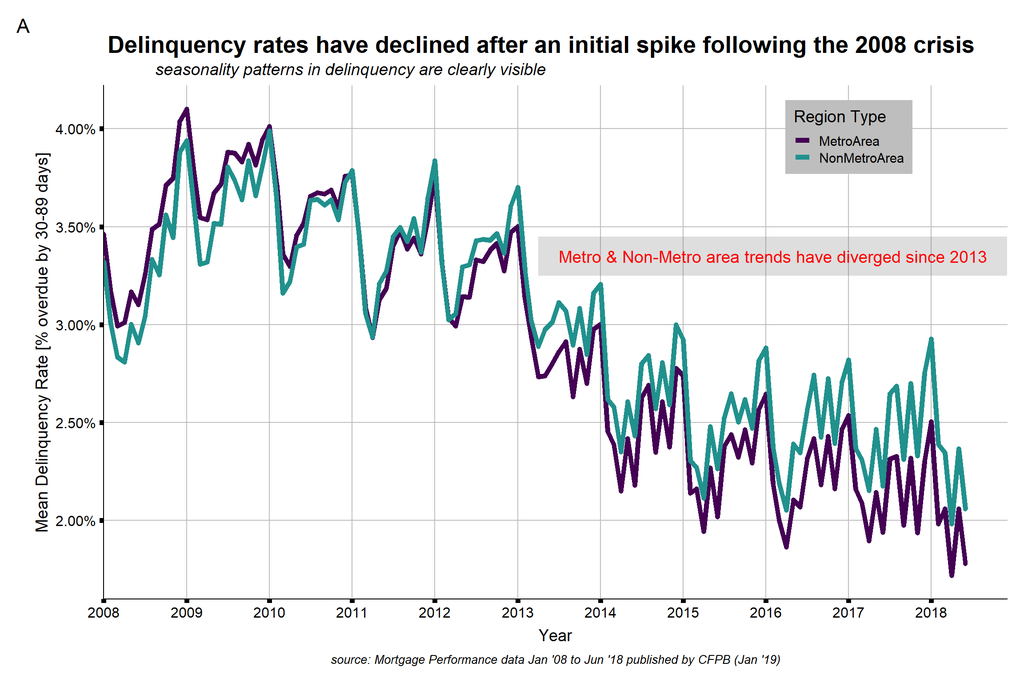

```r
# Plot delinquency trends by Region Type
p1 <- ggplot(filter(del_by_metro, grepl("Metro", RegionType)),
             aes(x=Month,
                 y=mean_del/100,
                 color=RegionType,
                 group=RegionType
                 )) +
  geom_point() +
  geom_line(size=2)

p1 +
  labs(colour = "Region Type",
       x = "Year",
       y = "Mean Delinquency Rate [% overdue by 30-89 days]",
       title = "Delinquency rates have declined after an initial spike following the 2008 crisis",
       subtitle = "seasonality patterns in delinquency are clearly visible",
       caption = "source: Mortgage Performance data Jan '08 to Jun '18 published by CFPB (Jan '19)",
       tag = "A") +
  scale_y_continuous(labels = scales::percent) +
  scale_x_date(date_breaks = "1 year",
               date_minor_breaks = "1 month",
               date_labels = "%Y",
               expand = c(0,0)) +
  annotate("rect",
           xmin=as.Date("2013-04-01", "%Y-%m-%d"),
           xmax=as.Date("2018-12-01", "%Y-%m-%d"),
           ymin=0.0325,
           ymax=0.0345,
           alpha=0.2) +
  annotate("text",
           x=as.Date("2016-02-01", "%Y-%m-%d"),
           y=0.0335,
           size=5,
           color="red",
           label="Metro & Non-Metro area trends have diverged since 2013") +
  standard_theme +
  theme(panel.grid.major = element_line(colour = "gray"),
        axis.text = element_text(colour = "black"),
        axis.ticks = element_line(size = 2),
        legend.position = c(0.825, 0.9),
        legend.background = element_rect(fill = "gray")) +
  scale_color_manual(values=c('#440154ff','#21918dff'))
```

### Differences across States

After analyzing the difference between metro and non-metro areas, we examine the difference across states. We look at the worst (highest) delinquency in metro areas across states and compare against the best (lowest) delinquency in metro areas across states. Similarly, we look at the difference between the state with the highest delinquency in non-metro areas and the state with the lowest delinquency in non-metro areas. We see that

1. there is again a clear cyclic or seasonal pattern difference between worst and least delinquency is highest during December and January (around the winter & holiday season when borrowers may prioritize other imminent expenses over repaying their mortgages) and the difference decreases over the next 3-4 months before increasing again
2. difference is higher for metro areas in every single month this indicates higher disparity across states when we consider only the metro or heavily urbanized areas, as against the countryside

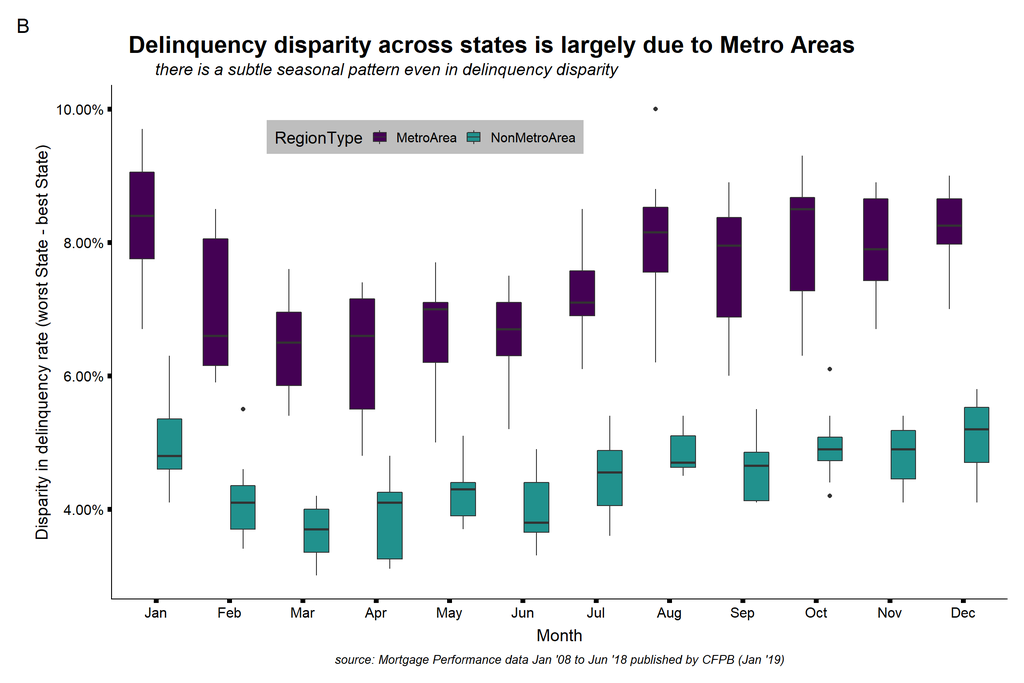

```r
# Plot disparity in delinquency (max - min) across states
p2 <- ggplot(filter(del_by_metro, grepl("Metro", RegionType)),
             aes(x=format(Month, "%m"),
                 y=del_diff/100,
                 fill=RegionType)) +
  geom_boxplot()

p2 + labs(colour = "Region Type",
          x = "Month",
          y = "Disparity in delinquency rate (worst State - best State)",
          title = "Delinquency disparity across states is largely due to Metro Areas",
          subtitle = "there is a subtle seasonal pattern even in delinquency disparity",
          caption = "source: Mortgage Performance data Jan '08 to Jun '18 published by CFPB (Jan '19)",
          tag = "B") +
  scale_y_continuous(labels = scales::percent) +
  scale_x_discrete("Month",
                   labels=month.abb
                   ) +
  standard_theme +
  theme(axis.ticks = element_line(size = 2),
        legend.position = c(0.35, 0.9),
        legend.background = element_rect(fill = "gray"),
        legend.direction = "horizontal"
        ) +
  scale_fill_manual(values=c('#440154ff','#21918dff'))
```

## Comparing trends in Delinquency & NPA rates

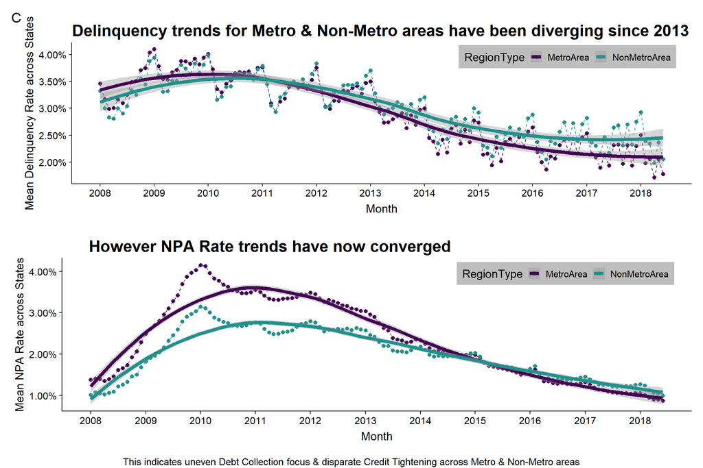

```r
# Mean Delinquency Trends
p3a <- ggplot(filter(del_by_metro, grepl("Metro", RegionType)),
              aes(x=Month,
                  y=mean_del/100,
                  color=RegionType,
                  group=RegionType
                  )) +
  geom_line(linetype = 2) +
  geom_point(size=2) +
  geom_smooth(aes(y=mean_del/100, group=RegionType), size=2) +
  scale_y_continuous(labels = scales::percent) +
  scale_x_date(date_breaks = "1 year",
               date_minor_breaks = "1 month",
               date_labels = "%Y") +
  scale_color_manual(values=c('#440154ff','#21918dff')) +
  standard_theme +
  theme(legend.position = c(0.8, 0.9),
        legend.background = element_rect(fill = "gray"),
        legend.direction = "horizontal"
        ) +
  labs(y = "Mean Delinquency Rate across States",
       title = "Delinquency trends for Metro & Non-Metro areas have been diverging since 2013",
       tag = "C"
       )

# Mean NPA Trends
p3b <- ggplot(filter(npa_by_metro, grepl("Metro", RegionType)),
              aes(x=Month,
                  y=mean_npa/100,
                  color=RegionType,
                  group=RegionType
                  )) +
  geom_line(linetype = 2) +
  geom_point(size=2) +
  geom_smooth(aes(y=mean_npa/100, group=RegionType), size=2) +
  scale_y_continuous(labels = scales::percent) +
  scale_x_date(date_breaks = "1 year",
               date_minor_breaks = "1 month",
               date_labels = "%Y") +
  scale_color_manual(values=c('#440154ff','#21918dff')) +
  standard_theme +
  theme(legend.position = c(0.8, 0.9),
        legend.background = element_rect(fill = "gray"),
        legend.direction = "horizontal"
        ) +
  labs(y = "Mean NPA Rate across States",
       title = "However NPA Rate trends have now converged"
       )

# Plot both one below the other
grid.arrange(p3a, p3b, nrow = 2,
             bottom = "This indicates uneven Debt Collection focus & disparate Credit Tightening across Metro & Non-Metro areas"
             )
```

## Examining Inter-State differences in Delinquency rates

A closer look at average delinquency rates by State indicates:

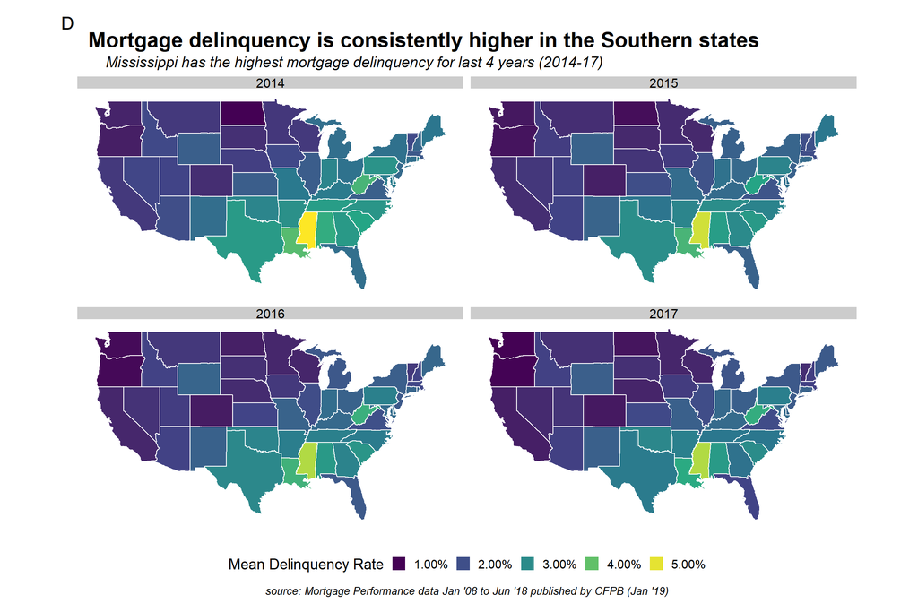

```r
# Convert state names to lowercase
del_state_long$Name <- tolower(del_state_long$Name)

# Month-on-month Delinquency Rates by State
del_by_state <- del_state_long %>%
  mutate(Year = year(Month)) %>%
  group_by(Name, Year) %>%
  summarise(mean_del = mean(delinquency_rate),
            max_del = max(delinquency_rate),
            min_del = min(delinquency_rate),
            del_diff = max_del - min_del)


states <- map_data("state")

# Merge with Map Data
del_state_map <- merge(states,
                       del_by_state %>% filter(Year >= 2014 &
                                                 Year <= 2017),
                       sort = FALSE,
                       by.x = "region",
                       by.y = "Name")

p4<- ggplot(del_state_map, aes(long, lat)) +
  geom_polygon(aes(fill = mean_del/100, group=group), color="white") +
  coord_fixed(1.3) +
  facet_wrap(~Year)

p4 + labs(colour = "Mean Delinquency Rate",
          x = "",
          y = "",
          title = "Mortgage delinquency is consistently higher in the Southern states",
          subtitle = "Mississippi has the highest mortgage delinquency for last 4 years (2014-17)",
          caption = "source: Mortgage Performance data Jan '08 to Jun '18 published by CFPB (Jan '19)",
          tag = "D") +
  scale_fill_viridis_c(labels = percent) +
  guides(fill=guide_legend(title="Mean Delinquency Rate",
                           title.position = "left",
                           label.position = "right"
                           )) +
  ditch_the_axes +
  standard_theme +
  theme(legend.position = "bottom", legend.box = "horizontal")
```

## Inter-State differences in NPA rates

NPA rates aggregated at the State level present a different picture:

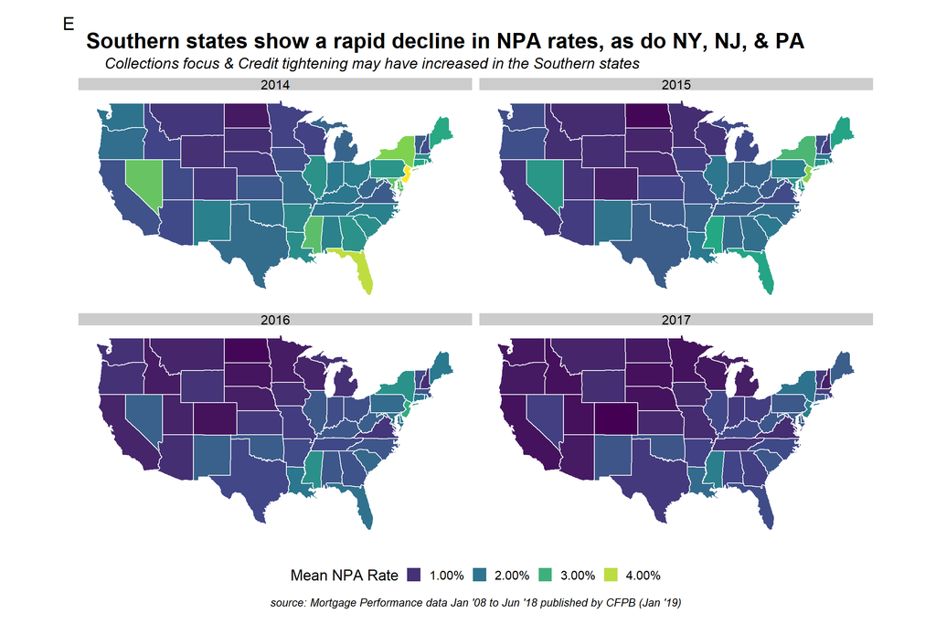

```r
# Convert state names to lowercase
npa_state_long$Name <- tolower(npa_state_long$Name)

# Month-on-month Delinquency Rates by State
npa_by_state <- npa_state_long %>%
  mutate(Year = year(Month)) %>%
  group_by(Name, Year) %>%
  summarise(mean_npa = mean(default_rate),
            max_npa = max(default_rate),
            min_npa = min(default_rate),
            npa_diff = max_npa - min_npa)

# Merge with Map Data
npa_state_map <- merge(states,
                       npa_by_state %>% filter(Year >= 2014 &
                                                 Year <= 2017),
                       sort = FALSE,
                       by.x = "region",
                       by.y = "Name")

p5<- ggplot(npa_state_map, aes(long, lat)) +
  geom_polygon(aes(fill = mean_npa/100, group=group), color="white") +
  coord_fixed(1.3) +
  facet_wrap(~Year)

p5 + labs(colour = "Mean NPA Rate",
          x = "",
          y = "",
          title = "Southern states show a rapid decline in NPA rates, as do NY, NJ, & PA",
          subtitle = "Collections focus & Credit tightening may have increased in the Southern states",
          caption = "source: Mortgage Performance data Jan '08 to Jun '18 published by CFPB (Jan '19)",
          tag = "E") +
  scale_fill_viridis_c(labels = percent) +
  guides(fill=guide_legend(title="Mean NPA Rate",
                           title.position = "left",
                           label.position = "right"
                           )) +
  ditch_the_axes +
  standard_theme +
  theme(legend.position = "bottom", legend.box = "horizontal")
```

## Insights from Consumer Complaints

The Consumer Financial Protection Bureau receives thousands of complaints from consumers every week, which are sent to the relevant banking or financial services provider for response. CFPB monitors every complaint for timely and accurate closure.

```r
# Transform Date complaint received by CFPB
complaints$Date_received <- as.Date(complaints$Date_received, "%m/%d/%Y")
complaints$Year_received <- as.numeric(format(complaints$Date_received, "%Y"))
complaints$Month_received <- floor_date(complaints$Date_received, "month")

# Transform Date complaint sent by CFPB to Company
complaints$Date_sent_to_company <- as.Date(complaints$Date_sent_to_company, "%m/%d/%Y")
complaints$Year_sent_to_company <- as.numeric(format(complaints$Date_sent_to_company, "%Y"))
complaints$Month_sent_to_company <- floor_date(complaints$Date_sent_to_company, "month")

# Filter out only Mortgage-related complaints
mort_comp <- filter(complaints,
                    Product == "Mortgage" & grepl("Conventional", Sub_product))

# Re-classify Complaint Types
mort_comp <- mort_comp %>% mutate(
  Issue_type = case_when(
    grepl("Appl", Issue) ~ "Accessibility",
    Issue == "Credit decision / Underwriting" ~ "Accessibility",
    Issue == "Struggling to pay mortgage" ~ "Stressed",
    grepl("collection", Issue) ~ "Stressed",
    grepl("escrow", Issue) ~ "Servicing",
    Issue == "Trouble during payment process" ~ "Servicing",
    TRUE ~ "Other"
    )
  )
```

```r
# Count of complaints received by Issue Type & Month
mort_comp_by_issue <- mort_comp %>%
  group_by(Issue_type, Month_received) %>%
  summarise(num_complaints = n())

# Count of complaints received by Issue Type & State every Year
mort_comp_by_state <- mort_comp %>%
  group_by(Issue_type, State, Year_received) %>%
  summarise(num_complaints = n())

# Calculate %complaints by State that are Stress related
mort_comp_by_state <- mort_comp_by_state %>%
  group_by(State, Year_received) %>%
  #mutate(comp_perc = num_complaints / sum(num_complaints))
  mutate(comp_perc = ifelse(num_complaints >= 30,
                            num_complaints / sum(num_complaints),
                            -0.1))
```

### Trends in Mortgage related complaints

Complaints related to Mortgages received from 2012 indicate

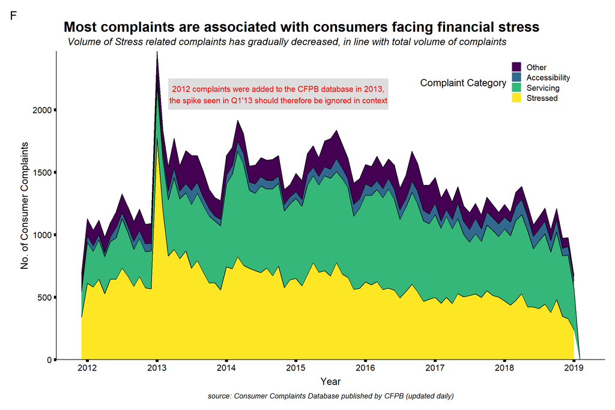

```r
# Plot monthly volume of complaints received by the CFPB
p7 <- ggplot(mort_comp_by_issue,
             aes(x=Month_received,
                 y=num_complaints,
                 fill=Issue_type,
                 group=Issue_type)) +
  geom_area() +
  geom_line(aes(ymax=num_complaints),
            position = "stack")

p7 + labs(colour = "Complaint Type",
          x = "Year",
          y = "No. of Consumer Complaints",
          title = "Most complaints are associated with consumers facing financial stress",
          subtitle = "Volume of Stress related complaints has gradually decreased, in line with total volume of complaints",
          caption = "source: Consumer Complaints Database published by CFPB (updated daily)",
          tag = "F") +
  scale_y_continuous(expand=c(0,0)) +
  scale_x_date(date_breaks = "1 year",
               date_minor_breaks = "1 month",
               date_labels = "%Y") +
  scale_fill_manual(values=viridis::viridis(4),
                    labels=c("Other","Accessibility","Servicing","Stressed")) +
  guides(fill=guide_legend(title="Complaint Category",
                           title.position = "left",
                           label.position = "right"
                           )) +
  annotate("rect",
           xmin=as.Date("2013-03-01", "%Y-%m-%d"),
           xmax=as.Date("2016-05-01", "%Y-%m-%d"),
           ymin=2000,
           ymax=2250,
           alpha=0.2) +
  annotate("text",
           x=as.Date("2014-10-01", "%Y-%m-%d"),
           y=2125,
           size=4,
           color="red",
           label="2012 complaints were added to the CFPB database in 2013,\nthe spike seen in Q1'13 should therefore be ignored in context") +
  standard_theme +
  theme(axis.ticks = element_line(size = 2),
        legend.position = c(0.8, 0.9)
        )
```

### Comparing across States

Comparing complaints received across states we see that:

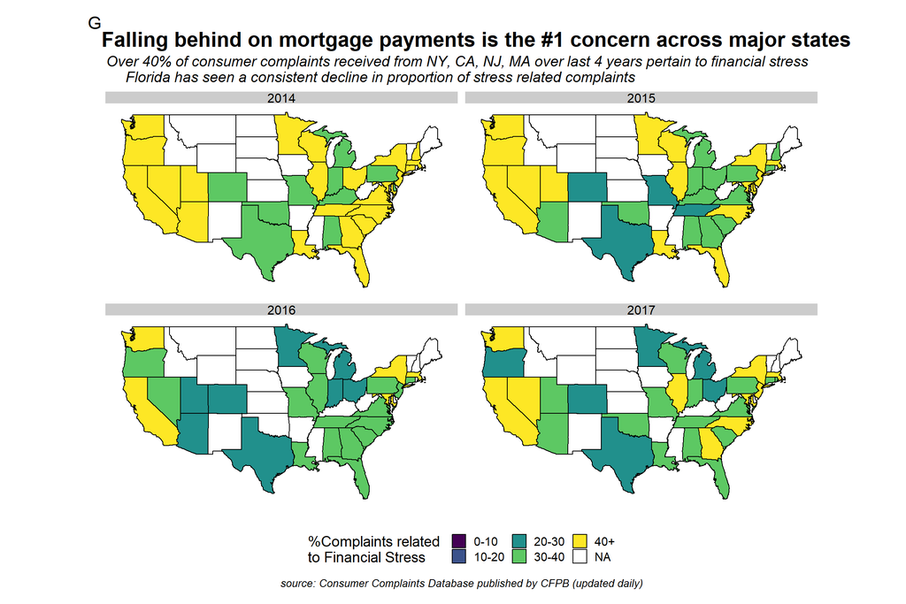

```r
# Convert state names to full names in lowercase
mort_comp_by_state$Statename <- tolower(abbr2state(mort_comp_by_state$State))

# Merge with Map Data
comp_state_map <- merge(states,
                        mort_comp_by_state %>% filter(Issue_type == "Stressed" &
                                                        Year_received >= 2014 &
                                                        Year_received <= 2017),
                        sort = FALSE,
                        by.x = "region",
                        by.y = "Statename")

# Create discrete bins based on %complaints related to Financial Stress
comp_state_map$perc_stress <- cut(comp_state_map$comp_perc,
                                  breaks=c(0, 0.1, 0.2, 0.3, 0.4, 1.0),
                                  labels=c("0-10","10-20","20-30","30-40","40+"))

# Plot proportion of Stress related complaints by State
p8 <- ggplot(comp_state_map, aes(long, lat)) +
  geom_polygon(aes(fill = perc_stress, group=group), color="black") +
  coord_fixed(1.3) +
  facet_wrap(~Year_received)

p8 + labs(colour = "%Complaints related to\n Financial Stress",
          x = "",
          y = "",
          title = "Falling behind on mortgage payments is the #1 concern across major states",
          subtitle = "Over 40% of consumer complaints received from NY, CA, NJ, MA over last 4 years pertain to financial stress\nFlorida has seen a consistent decline in proportion of stress related complaints",
          caption = "source: Consumer Complaints Database published by CFPB (updated daily)",
          tag = "G") +
  scale_fill_viridis_d(drop=FALSE) +
  guides(fill=guide_legend(title="%Complaints related \nto Financial Stress",
                           title.position = "left",
                           label.position = "right"
                           )) +
  ditch_the_axes +
  standard_theme +
  theme(legend.position = "bottom", legend.box = "horizontal")
```

## Diving deeper into New York, New Jersey, & Pennsylvania

Our analysis so far warrants a deeper dive into the 3 large Northeastern states of New York, New Jersey, and Pennsylvania. These states have similar population densities & comparable consumer profiles. The delinquency levels & trends across these 3 states have also been fairly similar. However, consumer complaints data shows a stark difference in self-reporting of Financial Stress.

- Delinquency rates across counties is fairly comparable, and the trend seems flat
- Philadelphia county does stand out across the last 4 years with the highest mean delinquency rate

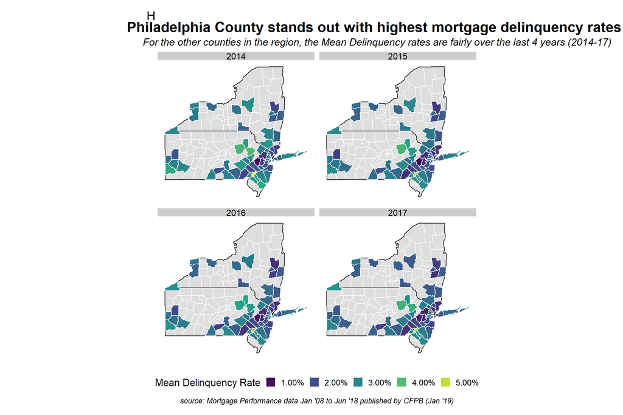

```r
# County map data
counties <- map_data("county")

# Delinquency Rates by County, convert state & county names to lowercase
del_county_long <- gather(select(del_county, -c(RegionType, FIPSCode)),
                          key = Month,
                          value = delinquency_rate,
                          convert = TRUE,
                          -c(State, Name)) %>%
  mutate(Month = as.Date(paste(Month,"-01",sep="")),
         Mth = format(Month, "%b"),
         region = tolower(abbr2state(State)),
         subregion = tolower(gsub("([A-Za-z]+).*",
                                  "\\1",
                                  Name)))

# Month-on-month Delinquency Rates by County Area
del_by_county <- del_county_long %>%
  mutate(Year = year(Month)) %>%
  group_by(region, subregion, Year) %>%
  summarise(mean_del = mean(delinquency_rate),
            max_del = max(delinquency_rate),
            min_del = min(delinquency_rate),
            del_diff = max_del - min_del)

# Merge with Map Data
del_county_map <- inner_join(counties,
                             del_by_county %>%
                               filter(region %in% c("new york",
                                                    "new jersey",
                                                    "pennsylvania") &
                                        Year >= 2014 &
                                        Year <= 2017),
                             by = c("region", "subregion"))

# Define Stata & County Level geographies
ne_df <- subset(states, region %in% c("new york", "new jersey", "pennsylvania"))
ne_county <- subset(counties, region %in% c("new york", "new jersey", "pennsylvania"))

# Define the base map
ne_base <- ggplot(data = ne_df, mapping = aes(x = long, y = lat, group = group)) +
  coord_fixed(1.3) +
  geom_polygon(data = ne_county, color = "white", fill="gray", alpha=0.5) +
  geom_polygon(color = "black", fill = "NA")

# Plot the Delinquency by County
p9 <- ne_base +
  geom_polygon(data = del_county_map,
               aes(fill = mean_del/100, group=group), color="white") +
  coord_fixed(1.3) +
  facet_wrap(~Year)

p9 + labs(colour = "Mean Delinquency Rate",
          x = "",
          y = "",
          title = "Philadelphia County stands out with highest mortgage delinquency rates across the 3 states",
          subtitle = "For the other counties in the region, the Mean Delinquency rates are fairly over the last 4 years (2014-17)",
          caption = "source: Mortgage Performance data Jan '08 to Jun '18 published by CFPB (Jan '19)",
          tag = "H") +
  scale_fill_viridis_c(labels = percent) +
  guides(fill=guide_legend(title="Mean Delinquency Rate",
                           title.position = "left",
                           label.position = "right"
                           )) +
  ditch_the_axes +
  standard_theme +
  theme(legend.position = "bottom", legend.box = "horizontal")
```

```r
knitr::opts_chunk$set(echo=TRUE,
                      message=FALSE,
                      warning=FALSE,
                      fig.width=12,
                      fig.height=8)
```

### Examining potential Credit Tightening across New York, New Jersey, & Pennsylvania

```r
# HMDA Loan Approvals data for NY, NJ, PA, CA, IL, TX, FL
hmda_states = read_csv("datasets/hmda/hmda_lar_large_states_14_17.csv")
```

```r
approved <- c("Loan originated","Application approved but not accepted")
booked <- c("Loan originated")

# Number of applications by Stata & Census Tract & Year
applied_county <- hmda_states %>%
  group_by(state_name, county_name, as_of_year) %>%
  summarise(applied = n())

# Number of Approved applications by Stata & Census Tract & Year
approved_county <- hmda_states %>%
  filter(action_taken_name %in% approved) %>%
  group_by(state_name, county_name, as_of_year) %>%
  summarise(approved = n())

# Number of Loands Originates / Final Booked by Stata & Census Tract & Year
booked_county <- hmda_states %>%
  filter(action_taken_name %in% booked) %>%
  group_by(state_name, county_name, as_of_year) %>%
  summarise(booked = n())

# Merge all together
process_rates_county <- applied_county %>%
  left_join(approved_county, by = c("state_name", "county_name", "as_of_year")) %>%
  left_join(booked_county, by = c("state_name", "county_name", "as_of_year")) %>%
  mutate(approval_rate = approved/applied,
         booking_rate = booked/approved,
         reject_rate = 1 - approval_rate,
         abnb_rate = 1 - booking_rate,
         loan_success_rate = booked/applied
         )
```

Approval Rates (proportion of New Home Purchase mortgages approved by a Financial Services firm or a Bank) are usually a strong and early indicator of Credit Tightening strategy adopted by the lenders. A persistent drop in Approval Rates would mean consumers face higher Credit Accessibility issues.

- We don’t see any particular decline in Approval Rates within a County
- Counties in the region differ in terms of mean Approval Rate, however most counties have a healthy approval rate between 70%-90%. Though approval rates might be shifting in terms of customer or property profiles, which need to be examined closely

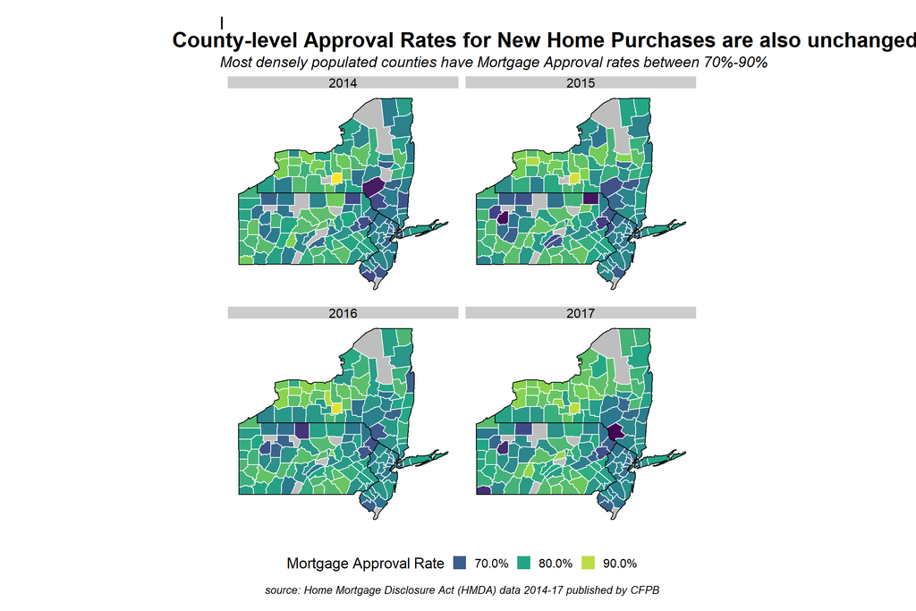

```r
# Map Data at State & County-level
states <- map_data("state")
counties <- map_data("county")

# Rectify State & County Names
process_rates_county <- process_rates_county %>%
  mutate(region = tolower(state_name),
         subregion = tolower(gsub("([A-Za-z]+).*",
                                  "\\1",
                                  county_name))
  )

# Define Stata & County Level geographies
ne_df <- subset(states, region %in% c("new york", "new jersey", "pennsylvania"))
ne_county <- subset(counties, region %in% c("new york", "new jersey", "pennsylvania"))

# Define the base map
ne_base <- ggplot(data = ne_df, mapping = aes(x = long, y = lat, group = group)) +
  coord_fixed(1.3) +
  geom_polygon(color = "black", fill = "gray")

# Join county map data with Process Rates
ne_rates <- inner_join(ne_county,
                       process_rates_county %>% filter(applied >= 100),
                       by = c("region","subregion"))

# Plot County-level Approval rates
ne_base +
  labs(colour = "Mean Delinquency Rate",
       x = "",
       y = "",
       title = "County-level Approval Rates for New Home Purchases are also unchanged in the last 4 years (2014-17)",
       subtitle = "Most densely populated counties have Mortgage Approval rates between 70%-90%",
       caption = "source: Home Mortgage Disclosure Act (HMDA) data 2014-17 published by CFPB",
       tag = "I") +
  geom_polygon(data = ne_rates,
               aes(fill = approval_rate),
               color = "white") +
  facet_wrap(~as_of_year) +
  geom_polygon(color = "black", fill = NA) +
  scale_fill_viridis_c(labels = percent) +
  ditch_the_axes +
  standard_theme +
  guides(fill=guide_legend(title="Mortgage Approval Rate",
                           title.position = "left",
                           label.position = "right"
                           )) +
  theme(legend.position = "bottom", legend.box = "horizontal")
```

## Impact on Property Tax collections

An increase in Financial Stress also leads to aggravated impact on the local economy. Consumers who fall behind on scheduled payments, are often forced to re-allocate their savings & downgrade their consumption. However, an often neglected secondary effect is the revenue loss to the local government, city or county. Reduced sales cause a dip in sales tax collections, while certain local governments may see a rise in Property Tax delinquencies as well. All such factors together cause additional stress to the City or County government’s finances, and in turn on the investment into community development initiatives.

One such example is the Philadelphia County in Pennsylvania. Thanks to the property-level property tax assessments and delinquencies published by the City Government on the OpenDataPhilly portal, we can analyze potential impact of Financial Stress on local government revenues.

```r
# Use ggmap to get Philly maptile
ph_map <- get_map(location = "Philadelphia County, Pennsylvania")

# Load Parcel-level Delinquency Shapefile
phl_taxdel <- read_sf("datasets/Philly_Council_Districts_2016/real_estate_tax_delinquencies.shp")

# Load City Council Districts Shapefile
phl_dist <- read_sf("datasets/Philly_Council_Districts_2016/Council_Districts_2016.shp")

# Filter out Serious Tax Delinquencies
phl_taxdel <- subset(phl_taxdel,
                     grepl("resid", building_1) &
                       (principal_ >= 3000) &
                       (oldest_yea >= 2009) &
                       (is_actiona == "true"))

# Calculate Centroids
phl_dist <- cbind(phl_dist, st_coordinates(st_centroid(phl_dist)))
phl_taxdel <- cbind(phl_taxdel, st_coordinates(st_centroid(phl_taxdel)))

# Nudge Centroid Labels on Y-axis
phl_dist$nudge_y <- 0
phl_dist$nudge_y[phl_dist$OBJECTID == 9] <- -1.0
phl_dist$nudge_y[phl_dist$OBJECTID == 10] <- -1.0
phl_dist$nudge_y[phl_dist$OBJECTID == 2] <- -1.0

# Nudge Centroid Labels on X-axis
phl_dist$nudge_x <- 0
phl_dist$nudge_x[phl_dist$OBJECTID == 4] <- 3.0
phl_dist$nudge_x[phl_dist$OBJECTID == 2] <- 2.5
phl_dist$nudge_x[phl_dist$OBJECTID == 6] <- 1.5
phl_dist$nudge_x[phl_dist$OBJECTID == 3] <- -1.5
phl_dist$nudge_x[phl_dist$OBJECTID == 10] <- 1.5
```

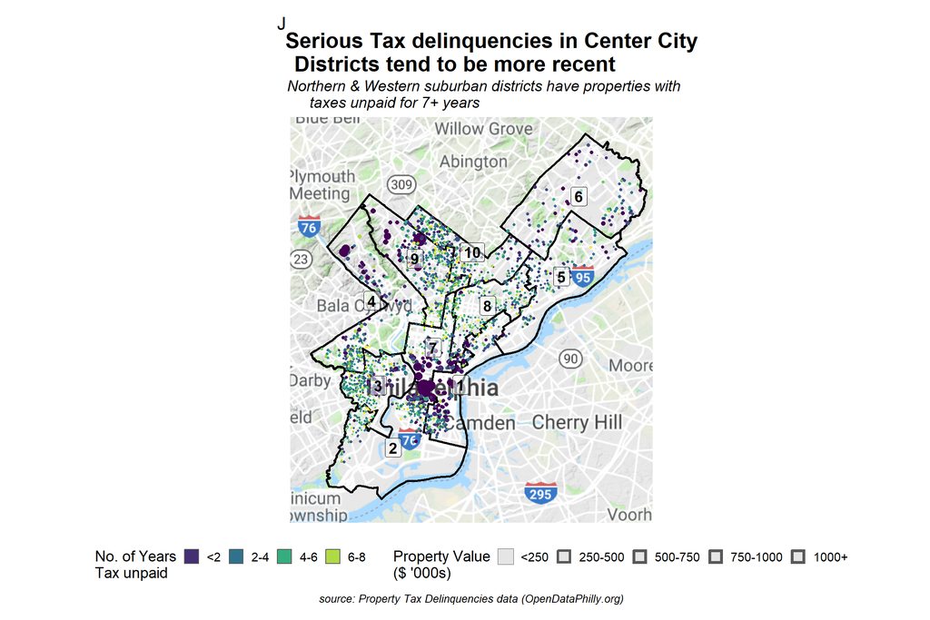

```r
# Plot Districts on Top of Geocoded Maptile
ggmap(ph_map) +
  geom_sf(data = phl_dist,
          inherit.aes = FALSE,
          fill=NA,
          color="black",
          size = 1) +
  geom_sf(data = phl_taxdel,
          inherit.aes = FALSE,
          aes(fill=num_years_,
              color=num_years_,
              size = total_asse)) +
  scale_color_viridis_c("No. of Years\nTax unpaid",
                       alpha = 1,
                       breaks = c(0, 2, 4, 6, 8, 20),
                       labels=c("0", "<2", "2-4", "4-6", "6-8", "8+"),
                       guide=FALSE) +
  scale_fill_viridis_c("No. of Years\nTax unpaid",
                       alpha = 1,
                       breaks = c(0, 2, 4, 6, 8, 20),
                       labels=c("0", "<2", "2-4", "4-6", "6-8", "8+")) +
  scale_size_area("Property Value\n($ '000s)",
                  trans = "identity",
                  breaks = c(0, 250000, 500000, 750000, 1000000),
                  labels = c("<250", "250-500", "500-750", "750-1000", "1000+")) +
  geom_label(data = phl_dist, inherit.aes = FALSE,
             aes(X, Y, label = OBJECTID), size = 5, fontface = "bold",
             alpha = 0.5,
             nudge_y = phl_dist$nudge_y,
             nudge_x = phl_dist$nudge_x) +
  coord_sf(xlim = c(-75.30, -74.95), ylim = c(39.85, 40.15), expand = TRUE) +
  labs(x = "",
       y = "",
       title = "Serious Tax delinquencies in Center City\nDistricts tend to be more recent",
       subtitle = "Northern & Western suburban districts have properties with\ntaxes unpaid for 7+ years",
       caption = "source: Property Tax Delinquencies data (OpenDataPhilly.org)",
       tag = "J") +
  guides(fill=guide_legend(title="No. of Years\nTax unpaid",
                           title.position = "left",
                           label.position = "right",
                           order = 0)) +
  ditch_the_axes +
  standard_theme +
  theme(legend.position = "bottom", legend.box = "horizontal")
```